# Shanghai Social Service Survey (SSSS)

3/5/2019

#### Shanghai Social Service Survey

This `README` is a brief documentation of Shanghai Social Service Survey (SSSS) which I conducted as part of my dissertation project. Respondents were sampled according to a multistage cluster sampling method. There are two parts to the survey. First is sampling beneficiaries of services and second is sampling non-beneficiaries. The survey was implemented with assistance from masters and undergraduate students at Fudan University from November 2017-January 2018 and March-June 2018. The students canvassed designated areas and recruited respondents by directly distributing QR code of the survey to the respondents so that they could respond using their smartphones. The survey was distributed using QQ survey platform.

##### Beneficiaries

Seven service organizations were sampled from a district-wise list of social service organization, which was created using official information on service organizations online. The district-wise lists were limited to five mid-low income districts in Shanghai. From seven service organizations, five service recipients were recruited as respondents for the survey. The total number of sampled beneficiaries was `N=35`.

##### Non-Beneficiaries

Because the service projects were neighborhood-based, the non-beneficiaries were sampled from the same neighborhood the respective service project was implemented. Six residential blocks (*xiaoqu*) were sampled from one neighborhood (*jiedao*), then two residents were sampled through canvassing. The survey questionnaire included questions on whether the respondent has had experience in receiving services from a service organization. If yes, this response was dropped, and more canvassing was conducted to reach the quota of two. The total number of sampled non-beneficiaries is `N=84`.

##### Limits in Inference

Both groups were sampled through a mix of multistage cluster sampling and non-probability sampling (NPS). NPS poses limits in external validity to the analysis done with the collected sample since the sample is not representative and could be biased. However, NPS was a feasible option for this study given the difficulty in obtaining household rosters for each residential blocks and identifying the non-beneficiary population itself. A list of service projects was also not publicly available due to decentralized government-NGO collaboration and outsourcing behavior.

##### Questionnaire

Questions in this survey included questions on perception towards services, such as service satisfaction, service efficacy (the belief whether one can affect the content of services), service accountability (who is accountable for the services). Also included were questions on political trust in different levels of government institutions, including the resident’s committee, neighborhood committee, local government, and the central government. Individual covariates were also collected, such as age, before-tax-income, household registration status, education level, employment status, and marriage status. Both service and trust constructs were measured using a five scale Likert-scale.

##### Districts Where Organizations Were Sampled From

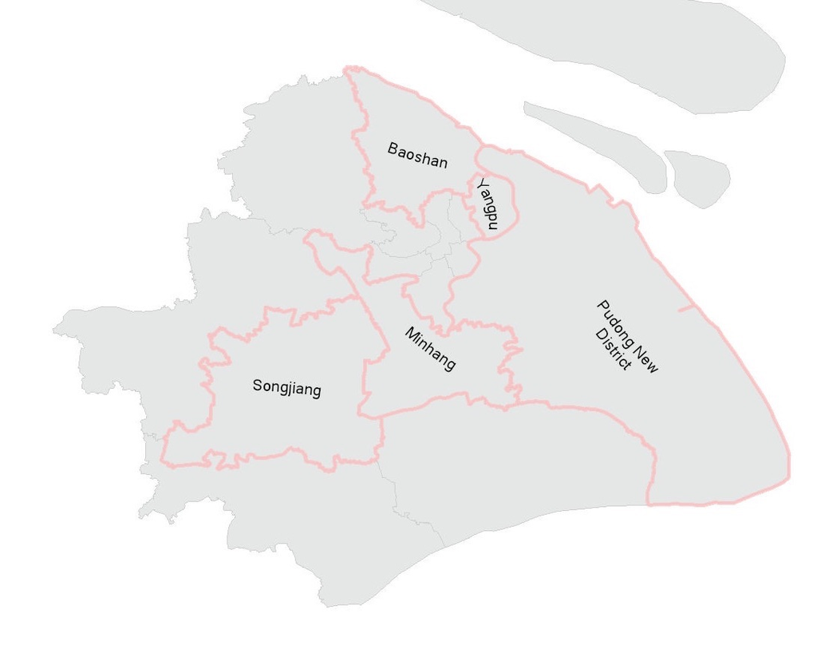

##### Comparing Beneficiaries and Non-Beneficiaries Sample

| Descriptive Statistics | Descriptive Statistics #Total Mean | Descriptive Statistics #Total | Descriptive Statistics #Total Std.dev. | Descriptive Statistics #Total | Descriptive Statistics #Total N | Descriptive Statistics | Descriptive Statistics ind_num Non-beneficiary Mean | Descriptive Statistics ind_num Non-beneficiary Std.dev. | Descriptive Statistics ind_num Non-beneficiary N | Descriptive Statistics ind_num | Descriptive Statistics ind_num Beneficiary Mean | Descriptive Statistics ind_num Beneficiary Std.dev. | Descriptive Statistics ind_num Beneficiary N |
| --- | --- | --- | --- | --- | --- | --- | --- | --- | --- | --- | --- | --- | --- |
| gender | 0.6 |  | 0.5 |  | 119 |  | 0.7 | 0.5 | 84 |  | 0.3 | 0.5 | 35 |
| household registration | 0.5 |  | 0.5 |  | 119 |  | 0.4 | 0.5 | 84 |  | 0.7 | 0.4 | 35 |
| trust in the resident’s committe | 3.4 |  | 1.1 |  | 119 |  | 3.2 | 1.1 | 84 |  | 4.0 | 1.0 | 35 |
| trust in the neighborhood committee | 3.6 |  | 1.1 |  | 119 |  | 3.4 | 1.1 | 84 |  | 4.0 | 0.9 | 35 |
| trust in the local government | 3.7 |  | 1.1 |  | 119 |  | 3.4 | 1.1 | 84 |  | 4.2 | 0.9 | 35 |
| trust in the central govenrment | 3.9 |  | 1.0 |  | 119 |  | 3.8 | 1.1 | 84 |  | 4.3 | 0.8 | 35 |
| satisfaction in services | 4.3 |  | 1.1 |  | 35 |  |  |  | 0 |  | 4.3 | 1.1 | 35 |
| service efficacy | 3.9 |  | 1.2 |  | 35 |  |  |  | 0 |  | 3.9 | 1.2 | 35 |

| Tabulation of Age | Tabulation of Age #Total | Tabulation of Age Non-beneficiary | Tabulation of Age Beneficiary |
| --- | --- | --- | --- |
| age |  |  |  |
| 10s | 9.2 | 9.5 | 8.6 |
| 20s | 29.4 | 40.5 | 2.9 |
| 30s | 24.4 | 29.8 | 11.4 |
| 40s | 11.8 | 11.9 | 11.4 |
| 50s | 8.4 | 3.6 | 20.0 |
| 60s | 11.8 | 3.6 | 31.4 |
| 70s | 5.0 | 1.2 | 14.3 |
| #Total cases | 119 | 84 | 35 |

| Tabulation of Income | Tabulation of Income #Total | Tabulation of Income Non-beneficiary | Tabulation of Income Beneficiary |
| --- | --- | --- | --- |
| annual before-tax income |  |  |  |
| 100 to 150 Thousand Yuan | 16.8 | 17.9 | 14.3 |
| 150 to 200 Thousand Yuan | 10.9 | 14.3 | 2.9 |
| 200 to 300 Thousand Yuan | 5.0 | 7.1 |  |
| 300 to 500 Thousand Yuan | 6.7 | 8.3 | 2.9 |
| 50 to 100 Thousand Yuan | 26.9 | 25.0 | 31.4 |
| Less than 50 Thousand Yuan | 31.9 | 25.0 | 48.6 |
| More than 500 Thousand Yuan | 1.7 | 2.4 |  |
| #Total cases | 119 | 84 | 35 |

The tables above compare the attributes between the beneficiaries and the non-beneficiaries sample. Compared to the non-beneficiaries sample, the beneficiaries sample is older. There were more respondents who were over 50s in the beneficiaries sample compared to the non-beneficiaries sample, where as there were more younger respondents in the non-beneficiaries sample. This different propportion of younger respondents reflect canvasser bias: because canvassers were in their 20s and 30s, the quota-sampling procedure biased their collection of sample towards younger population. Beneficiaries were more likely to be female than male, hold household registration, and have lower income. When examining the dependent variable of interest, the beneficiaries were slightly higher on trust scales compared to the non-beneficiary sample. For instance, mean of trust in the neighborhood committee was 3.4 for the non-beneficiaries sample, but was 4.0 for the beneficiaries sample.